# Advanced Speed and Accuracy Topics

This is going to be a bird's eye view of some of the advanced topics in Julia, particularly focusing on issues of speed and performance.

Julia is built with a number of components which enable it to obtain massive performance, despite its scripted nature. You've already seen

- multiple dispatch
- types, when necessary

We are skipping the built-in parallelism. This is for the very good reason that, even though it's designed-in from the outset of the language the syntax is currently being stabilised and should be final from the next release (*the disadvantage of being an early adopter*).

## Calling a C function natively

We can call **C** and **Fortran** functions natively. That means that you can potentially have an ultra high-performance library, which has been worked on for years, and you get to access its functions directly from Julia at **0** computational overhead.

> ccall((:function_name, "library_name"), return_type, (argument_types), argument_values)

Current requirements: the library must be *dynamically* linkable (not static).

Note that, getting the function call syntax correct is typically the biggest stumbling block to working with C and Fortran libraries from Julia. In addition, you don't have the benefit of interfacing via header files so the handling of returned values can be tricky if they're not what you were expecting.

Also, for Fortran users, you should note that Fortran compilers often change the case of a function call. From Julia you need to call the *compiled* version of the function call, not the original source code spelling.

```julia
@show ccall((:clock,),Int64,())
@show ccall((:clock,),Int64,())
@show ccall((:clock,),Int64,())
```

```
ccall((:clock,), Int64, ()) = 3553269
ccall((:clock,), Int64, ()) = 3693337
ccall((:clock,), Int64, ()) = 3699727
```

```
3699727
```

```julia
@show ccall((:rand,), Int64, ())
@show ccall((:rand,), Int64, ())
@show ccall((:rand,), Int64, ())
```

```
ccall((:rand,), Int64, ()) = 1458777923
ccall((:rand,), Int64, ()) = 2007237709
ccall((:rand,), Int64, ()) = 823564440
```

```
823564440
```

```julia
ccall((:printf,), Int64, (Cstring,), "blah")
```

```
blah
```

```
4
```

```julia
ccall((:printf,), Int64, (Cstring,Int64), "blah %d \n", 999)
```

```
blah 999
```

```
10
```

```julia
function getenv(var::AbstractString)
    val = ccall((:getenv, "libc"),
                Cstring, (Cstring,), var)
    if val == C_NULL
        error("getenv: undefined variable: ", var)
    end
    unsafe_string(val)
end
```

```
getenv (generic function with 1 method)
```

```julia
getenv("PATH")
```

```
"/Applications/Julia-0.6.app/Contents/Resources/julia/bin:/Applications/Julia-0.6.app/Contents/Resources/julia/bin:/Users/davidhiggins/anaconda/bin:/Users/davidhiggins/anaconda/bin:~/.local/bin:/Applications/Julia-0.5.app/Contents/Resources/julia/bin:/opt/local/bin:/opt/local/sbin:/usr/local/git/bin…
```

```julia
getenv("THIS_value_DOESNT_exist")
```

```
getenv: undefined variable: THIS_value_DOESNT_exist

Stacktrace:
 [1] getenv(::String) at ./In[5]:5
```

In practice, you may never need to use this functionality depending on your position on the power-user spectrum.

But even if you're not using it directly, under the hood this is how many of the Packages are interfacing with numerical libraries which have been developed and optimised in C and Fortran since the 70's.

https://docs.julialang.org/en/stable/manual/calling-c-and-fortran-code/

## OpenCL

I use OpenCL extensively in my work. You may be familiar with CUDA. There is also a CUDAnative package for Julia. The principles I'm going to present are similar for both interfaces.

OpenCL will work out of the box for Mac users. For Windows and Linux users it typically requires some external packages be installed. This is not a workshop on OpenCL, so we'll provide a notebook with the calculated outputs which you can follow, but please note when installing OpenCL that you need a **driver** or a **library** which provides OpenCL support directly for your system and not just the **header** files. (apt-get install opencl typically only grabs the headers)

If you want to install OpenCL (after the workshop) there are a number of options:

1. If you have an NVIDIA GPU then you automatically have OpenCL installed if you install CUDA development system. Note that the NVIDIA implementation can only compile OpenCL for the GPU device.
2. You can install ATIs APP SDK, which is natively OpenCL, for ATI GPU devices. *This system can also compile for CPU giving you the best of both worlds!*
3. Intel provide OpenCL compilers for CPUs.
4. Apple pre-install OpenCL support on their computers, for both CPU and GPU.

```julia
Pkg.add("OpenCL")
```

```julia
using OpenCL
```

The writers of the OpenCL package have made extensive use of the ccall( ) approach to directly interface with OpenCL (which is typically accessed from C).

Here I will present a few wrapper functions, which I have written, which most OpenCL developers typically need to write themselves when they begin using the langauge.

```julia
function print_cl_stuff()
    print("Number of Platforms: ", cl.num_platforms(), "\n")
    for plat in cl.num_platforms()
        print("Platform[", plat, "]: ", cl.platforms()[plat], "\n")
        #print("Platforms: ", cl.platforms())
        numdevices = length(cl.devices())
        print("\tNumber of Devices: ", numdevices, "\n")
        for dev = 1:numdevices
            print("\tDevice[", dev, "]: ", cl.devices()[dev], "\n")
        end
        #print("\nDevices: ", cl.devices(), "\n")
    end
end
```

```
print_cl_stuff (generic function with 1 method)
```

Here we're making use of the following functions.

> cl.num_platforms( )

> cl.platforms( )[index]

> cl.devices( )

> cl.devices( )[index]

These are **very** lightly wrapped versions of the C functions which are part of the OpenCL API.

```julia
print_cl_stuff()
```

```
Number of Platforms: 1
Platform[1]: OpenCL.Platform('Apple' @0x000000007fff0000)
	Number of Devices: 2
	Device[1]: OpenCL.Device(Intel(R) Core(TM) i5-4308U CPU @ 2.80GHz on Apple @0x00000000ffffffff)
	Device[2]: OpenCL.Device(Iris on Apple @0x0000000001024500)
```

In OpenCL you may have multiple platforms installed on your system (these are the different implementations mentioned in the install notes above).

When you're setting up a computation, you need to choose:

- platform
- device

and create a memory (plus device)

- context

This latter is basically the namespace within which your computation will operate.

```julia
function set_device(device_id, platform)
    device = cl.devices()[device_id]
    return device
end

function set_device(device_id)
    platform = set_platform()
    return set_device(device_id, platform)
end

function set_context(device)
    ctx = cl.Context(device)
    return ctx
end

function set_platform(platform_id=0)
    platform = cl.Platform(platform_id)
    return platform
end;
```

```julia
our_platform = set_platform()
```

```
OpenCL.Platform('Apple' @0x0000000000000000)
```

```julia
cl.Platform(0)
```

```
OpenCL.Platform('Apple' @0x0000000000000000)
```

Setting the platform defaults to the first one (since there is often only one installed platform).

```julia
our_device = set_device(1)
```

```
OpenCL.Device(Intel(R) Core(TM) i5-4308U CPU @ 2.80GHz on Apple @0x00000000ffffffff)
```

Notice that the indexing of the array here is 1 based, as it's still in Julia. However the platform id above is indexed from 0 as it's a value which is directly passed to the C function.

```julia
cl.devices()[2]
```

```
OpenCL.Device(Iris on Apple @0x0000000001024500)
```

```julia
our_context = set_context(our_device)
```

```
OpenCL.Context(@0x00007fbc94bd3ab0 on Intel(R) Core(TM) i5-4308U CPU @ 2.80GHz)
```

We now have access to device 1, via our_context, and we have a handle for our_platform. These are all necessary components for running an OpenCL kernel.

```julia
cl.CLError(-10)
```

```
CLError(code=-10, CL_IMAGE_FORMAT_NOT_SUPPORTED)
```

Many functions in OpenCL can return an error code. This has its own format but you can access it via CLError.

```julia
cl.error_description(cl.CLError(-10))
```

```
UndefVarError: _cl_error_descriptions not defined

Stacktrace:
 [1] error_description(::OpenCL.cl.CLError) at /Users/davidhiggins/.julia/v0.6/OpenCL/src/error.jl:191
```

Normally the above line will work. But the version of the package that I was working with had a bug. I've submitted a pull request so it will hopefully work by the time of the workshop.

In any case, the expected behaviour is to print out a useful string regarding the meaning of any returned error code.

Note that OpenCL does not provide this functionality, this is a feature of the Julia OpenCL package.

## OpenCL showcase example

*based on code written by Thomas McColgan and Rike Schuppner at a workshop in Lychen, 2017*

```julia
diff_kernel = "
inline int xy_to_i(int x, int y, int col_size, int mesh_size) {
    return (x % col_size) + (y % col_size) * col_size;
}

__kernel void diff(__global const float *a,
__global float *diff,
int col_size,
int mesh_size)
    {
      int gid = get_global_id(0);
    int x_idx = gid % col_size;
    int y_idx = gid / col_size;

    diff[gid] = - 4. * a[gid]
    + a[xy_to_i(x_idx - 1, y_idx, col_size, mesh_size)]
    + a[xy_to_i(x_idx + 1, y_idx, col_size, mesh_size)]
    + a[xy_to_i(x_idx, y_idx - 1, col_size, mesh_size)]
    + a[xy_to_i(x_idx, y_idx + 1, col_size, mesh_size)];
    }
";
```

```julia
sum_kernel = "
   __kernel void sum(__global float *a,
__global const float *diff,
float step_size)
    {
      int gid = get_global_id(0);
    a[gid] += step_size * diff[gid];
    }
";
```

OpenCL allows us to run **kernels** on the GPU/CPU device.

In our example each parallel computational unit operates its own version of the *kernel* on a different unit in an array.

```julia
function initial_cond(big_array=true)
    if big_array
        a = zeros(Float32, (5000, 5000))
    else
        a = zeros(Float32, (1000, 1000))
    end
    a[Int(size(a)[1] / 2), Int(size(a)[2] / 2)] = 10000
    return a
end;
```

```julia
function do_openCL(input, device_index=1)
#    device, ctx, queue = cl.create_compute_context()
#    print(device, ctx, queue)
    device = set_device(device_index)
    # on my system device 1 is CPU, device 2 is GPU
    ctx = set_context(device)
    queue  = cl.CmdQueue(ctx)
    print(ctx, device, queue)

    input_buff = cl.Buffer(Float32, ctx, (:rw, :copy), hostbuf=input)
    diff_buff = cl.Buffer(Float32, ctx, :rw, length(input))

    diff_p = cl.Program(ctx, source=diff_kernel) |> cl.build!
    diff_k = cl.Kernel(diff_p, "diff")

    sum_p = cl.Program(ctx, source=sum_kernel) |> cl.build!
    sum_k = cl.Kernel(sum_p, "sum")

    step_size = 0.001

    for i in 1:1000
        queue(diff_k, length(input), nothing, input_buff, diff_buff, size(input)[1], length(input))
        queue(sum_k, length(input), nothing, input_buff, diff_buff, Float32(step_size))
    end
    r = cl.read(queue, input_buff);
    r = reshape(r, size(input))
    return r
end
```

```
do_openCL (generic function with 2 methods)
```

```julia
@time do_openCL(initial_cond(true), 2);
```

```
OpenCL.Context(@0x00007fbc94d77820 on Iris)OpenCL.Device(Iris on Apple @0x0000000001024500)OpenCL.CmdQueue(@0x00007fbc94be1550) 32.532243 seconds (455.68 k allocations: 213.876 MiB, 0.50% gc time)
```

Running on the GPU is reasonably quick, considering the size of the system. My system typically takes 35secs.

The big array system has a 5000x5000 array and we loop 1000 times across this, performing a number of summation and multiplication operations on every element.

```julia
@time plot_result_cpu = do_openCL(initial_cond(false), 1);
```

```
OpenCL.Context(@0x00007fbc94c892f0 on Intel(R) Core(TM) i5-4308U CPU @ 2.80GHz)OpenCL.Device(Intel(R) Core(TM) i5-4308U CPU @ 2.80GHz on Apple @0x00000000ffffffff)OpenCL.CmdQueue(@0x00007fbc94c79380) 13.551928 seconds (87.32 k allocations: 10.011 MiB)
```

Running on the CPU is very slow. The big array takes >5 mins on my laptop.

So here I've set a flag to false to run an array which is 25 times smaller. It still takes 15 secs on the CPU.

```julia
(25*15) / 60
```

```
6.25
```

```julia
@time plot_result_gpu = do_openCL(initial_cond(false), 2);
```

```
OpenCL.Context(@0x00007fbc94c7eca0 on Iris)OpenCL.Device(Iris on Apple @0x0000000001024500)OpenCL.CmdQueue(@0x00007fbc94ca2940)  1.916094 seconds (87.32 k allocations: 10.010 MiB)
```

We can run that small system here on the GPU. We see a decent speed-up relative to CPU, on my system the time is now 2 secs, but on such a small system it is no longer dramatic.

```julia
function diff_step(input, output)
    maxX, maxY = size(input)
    for iter in eachindex(input)
        x, y = ind2sub(input, iter)
        output[iter] = - 4. * input[iter] + input[x, y - 1 == 0 ? maxY : y - 1] +
        input[x, y + 1 > maxY ? 1 : y + 1] +
        input[x - 1 == 0 ? maxX : x - 1, y] +
        input[x + 1 > maxX ? 1 : x + 1, y]
    end
    return output
end

function sum_step(input, diff, step_size)
    return input + (step_size * diff)
end

function do_naive(input)
    step_size = 0.001

    diff = similar(input)
    for i in 1:1000
        diff = diff_step(input, diff)
        input = sum_step(input, diff, step_size)
    end
    return input
end;
```

We can implement a *very* naive version here in non-optimised pure Julia, to see if there is much overhead using OpenCL.

```julia
@time naive_result = do_naive(initial_cond(false));
```

```
 24.539885 seconds (206.32 k allocations: 14.918 GiB, 7.90% gc time)
```

This comes in at 26 secs on my machine. Compared with 2 secs for OpenCL on GPU and 15 secs for OpenCL on CPU.

Let's be clear, this is because we are operating in a regime which is particularly suitable for GPU computing here!

```julia
initial_conditions_array = initial_cond(false)
```

```
1000×1000 Array{Float32,2}:
 0.0  0.0  0.0  0.0  0.0  0.0  0.0  0.0  …  0.0  0.0  0.0  0.0  0.0  0.0  0.0
 0.0  0.0  0.0  0.0  0.0  0.0  0.0  0.0     0.0  0.0  0.0  0.0  0.0  0.0  0.0
 0.0  0.0  0.0  0.0  0.0  0.0  0.0  0.0     0.0  0.0  0.0  0.0  0.0  0.0  0.0
 0.0  0.0  0.0  0.0  0.0  0.0  0.0  0.0     0.0  0.0  0.0  0.0  0.0  0.0  0.0
 0.0  0.0  0.0  0.0  0.0  0.0  0.0  0.0     0.0  0.0  0.0  0.0  0.0  0.0  0.0
 0.0  0.0  0.0  0.0  0.0  0.0  0.0  0.0  …  0.0  0.0  0.0  0.0  0.0  0.0  0.0
 0.0  0.0  0.0  0.0  0.0  0.0  0.0  0.0     0.0  0.0  0.0  0.0  0.0  0.0  0.0
 0.0  0.0  0.0  0.0  0.0  0.0  0.0  0.0     0.0  0.0  0.0  0.0  0.0  0.0  0.0
 0.0  0.0  0.0  0.0  0.0  0.0  0.0  0.0     0.0  0.0  0.0  0.0  0.0  0.0  0.0
 0.0  0.0  0.0  0.0  0.0  0.0  0.0  0.0     0.0  0.0  0.0  0.0  0.0  0.0  0.0
 0.0  0.0  0.0  0.0  0.0  0.0  0.0  0.0  …  0.0  0.0  0.0  0.0  0.0  0.0  0.0
 0.0  0.0  0.0  0.0  0.0  0.0  0.0  0.0     0.0  0.0  0.0  0.0  0.0  0.0  0.0
 0.0  0.0  0.0  0.0  0.0  0.0  0.0  0.0     0.0  0.0  0.0  0.0  0.0  0.0  0.0
 ⋮                        ⋮              ⋱            ⋮
 0.0  0.0  0.0  0.0  0.0  0.0  0.0  0.0     0.0  0.0  0.0  0.0  0.0  0.0  0.0
 0.0  0.0  0.0  0.0  0.0  0.0  0.0  0.0     0.0  0.0  0.0  0.0  0.0  0.0  0.0
 0.0  0.0  0.0  0.0  0.0  0.0  0.0  0.0  …  0.0  0.0  0.0  0.0  0.0  0.0  0.0
 0.0  0.0  0.0  0.0  0.0  0.0  0.0  0.0     0.0  0.0  0.0  0.0  0.0  0.0  0.0
 0.0  0.0  0.0  0.0  0.0  0.0  0.0  0.0     0.0  0.0  0.0  0.0  0.0  0.0  0.0
 0.0  0.0  0.0  0.0  0.0  0.0  0.0  0.0     0.0  0.0  0.0  0.0  0.0  0.0  0.0
 0.0  0.0  0.0  0.0  0.0  0.0  0.0  0.0     0.0  0.0  0.0  0.0  0.0  0.0  0.0
 0.0  0.0  0.0  0.0  0.0  0.0  0.0  0.0  …  0.0  0.0  0.0  0.0  0.0  0.0  0.0
 0.0  0.0  0.0  0.0  0.0  0.0  0.0  0.0     0.0  0.0  0.0  0.0  0.0  0.0  0.0
 0.0  0.0  0.0  0.0  0.0  0.0  0.0  0.0     0.0  0.0  0.0  0.0  0.0  0.0  0.0
 0.0  0.0  0.0  0.0  0.0  0.0  0.0  0.0     0.0  0.0  0.0  0.0  0.0  0.0  0.0
 0.0  0.0  0.0  0.0  0.0  0.0  0.0  0.0     0.0  0.0  0.0  0.0  0.0  0.0  0.0
```

```julia
extrema(initial_conditions_array)
```

```
(0.0f0, 10000.0f0)
```

```julia
size(initial_conditions_array)
```

```
(1000, 1000)
```

```julia
plot_result_cpu
```

```
1000×1000 Array{Float32,2}:
 0.0  0.0  0.0  0.0  0.0  0.0  0.0  0.0  …  0.0  0.0  0.0  0.0  0.0  0.0  0.0
 0.0  0.0  0.0  0.0  0.0  0.0  0.0  0.0     0.0  0.0  0.0  0.0  0.0  0.0  0.0
 0.0  0.0  0.0  0.0  0.0  0.0  0.0  0.0     0.0  0.0  0.0  0.0  0.0  0.0  0.0
 0.0  0.0  0.0  0.0  0.0  0.0  0.0  0.0     0.0  0.0  0.0  0.0  0.0  0.0  0.0
 0.0  0.0  0.0  0.0  0.0  0.0  0.0  0.0     0.0  0.0  0.0  0.0  0.0  0.0  0.0
 0.0  0.0  0.0  0.0  0.0  0.0  0.0  0.0  …  0.0  0.0  0.0  0.0  0.0  0.0  0.0
 0.0  0.0  0.0  0.0  0.0  0.0  0.0  0.0     0.0  0.0  0.0  0.0  0.0  0.0  0.0
 0.0  0.0  0.0  0.0  0.0  0.0  0.0  0.0     0.0  0.0  0.0  0.0  0.0  0.0  0.0
 0.0  0.0  0.0  0.0  0.0  0.0  0.0  0.0     0.0  0.0  0.0  0.0  0.0  0.0  0.0
 0.0  0.0  0.0  0.0  0.0  0.0  0.0  0.0     0.0  0.0  0.0  0.0  0.0  0.0  0.0
 0.0  0.0  0.0  0.0  0.0  0.0  0.0  0.0  …  0.0  0.0  0.0  0.0  0.0  0.0  0.0
 0.0  0.0  0.0  0.0  0.0  0.0  0.0  0.0     0.0  0.0  0.0  0.0  0.0  0.0  0.0
 0.0  0.0  0.0  0.0  0.0  0.0  0.0  0.0     0.0  0.0  0.0  0.0  0.0  0.0  0.0
 ⋮                        ⋮              ⋱            ⋮
 0.0  0.0  0.0  0.0  0.0  0.0  0.0  0.0     0.0  0.0  0.0  0.0  0.0  0.0  0.0
 0.0  0.0  0.0  0.0  0.0  0.0  0.0  0.0     0.0  0.0  0.0  0.0  0.0  0.0  0.0
 0.0  0.0  0.0  0.0  0.0  0.0  0.0  0.0  …  0.0  0.0  0.0  0.0  0.0  0.0  0.0
 0.0  0.0  0.0  0.0  0.0  0.0  0.0  0.0     0.0  0.0  0.0  0.0  0.0  0.0  0.0
 0.0  0.0  0.0  0.0  0.0  0.0  0.0  0.0     0.0  0.0  0.0  0.0  0.0  0.0  0.0
 0.0  0.0  0.0  0.0  0.0  0.0  0.0  0.0     0.0  0.0  0.0  0.0  0.0  0.0  0.0
 0.0  0.0  0.0  0.0  0.0  0.0  0.0  0.0     0.0  0.0  0.0  0.0  0.0  0.0  0.0
 0.0  0.0  0.0  0.0  0.0  0.0  0.0  0.0  …  0.0  0.0  0.0  0.0  0.0  0.0  0.0
 0.0  0.0  0.0  0.0  0.0  0.0  0.0  0.0     0.0  0.0  0.0  0.0  0.0  0.0  0.0
 0.0  0.0  0.0  0.0  0.0  0.0  0.0  0.0     0.0  0.0  0.0  0.0  0.0  0.0  0.0
 0.0  0.0  0.0  0.0  0.0  0.0  0.0  0.0     0.0  0.0  0.0  0.0  0.0  0.0  0.0
 0.0  0.0  0.0  0.0  0.0  0.0  0.0  0.0     0.0  0.0  0.0  0.0  0.0  0.0  0.0
```

```julia
extrema(plot_result_cpu)
```

```
(0.0f0, 950.4539f0)
```

```julia
size(plot_result_cpu)
```

```
(1000, 1000)
```

```julia
initial_conditions_array[initial_conditions_array.>0]
```

```
1-element Array{Float32,1}:
 10000.0
```

```julia
plot_result_cpu[plot_result_cpu.>0]
```

```
3909-element Array{Float32,1}:
 2.94273f-44
 1.17709f-43
 2.95674f-43
 4.30199f-43
 2.95674f-43
 1.17709f-43
 2.94273f-44
 5.60519f-44
 3.36312f-43
 1.49799f-42
 5.02225f-42
 1.19279f-41
 1.73817f-41
 ⋮
 1.19279f-41
 5.02225f-42
 1.49799f-42
 3.36312f-43
 5.60519f-44
 2.94273f-44
 1.17709f-43
 2.95674f-43
 4.30199f-43
 2.95674f-43
 1.17709f-43
 2.94273f-44
```

```julia
using PyPlot
```

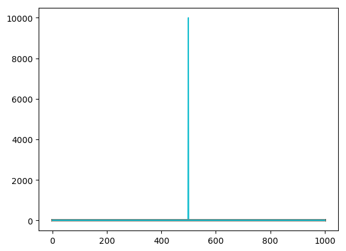

```julia
plot(initial_conditions_array);
```

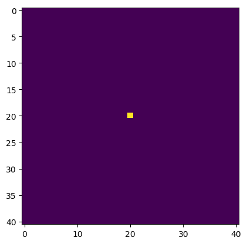

```
PyObject <matplotlib.image.AxesImage object at 0x122580110>
```

```julia
imshow(initial_conditions_array[480:520,480:520])
```

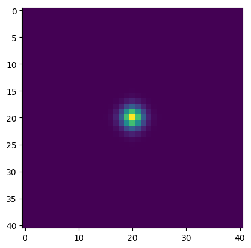

```
PyObject <matplotlib.image.AxesImage object at 0x122641410>
```

```julia
imshow(plot_result_cpu[480:520,480:520])
```

We've focused our plot on the area where something is happening. For this particular process, for only 1000 time steps, we could have simulated a 40x40 area instead of 1000x1000.

## Timing, Benchmarking & Profiling

### Timing

```julia
function do_my_loop(value)
    A = zeros(value, value)
    for i = 1:value, j = 1:value
        A[i,j] = i+j
    end
    return A;
end
```

```
do_my_loop (generic function with 1 method)
```

```julia
@time do_my_loop(1000);
```

```
  0.046382 seconds (5.43 k allocations: 7.926 MiB, 20.27% gc time)
```

By now you've seen me using the @time macro

```julia
@time do_my_loop(10000);
```

```
  2.832860 seconds (6 allocations: 762.940 MiB, 0.62% gc time)
```

```julia
function alternative_do_my_loop(value)
    A = Array{Float64,2}(value, value)
    for i = 1:value, j = 1:value
        A[i,j] = i+j
    end
    return A;
end
```

```
alternative_do_my_loop (generic function with 1 method)
```

```julia
@time alternative_do_my_loop(10000);
```

```
  2.469482 seconds (1.98 k allocations: 763.042 MiB, 7.63% gc time)
```

```julia
function final_alternative_do_my_loop(value)
    A = Array{Float64,2}(value, value)
    A = [i+j for i=1:value, j=1:value]
    return A;
end
```

```
final_alternative_do_my_loop (generic function with 1 method)
```

```julia
@time final_alternative_do_my_loop(10000);
```

```
  0.897162 seconds (25.83 k allocations: 1.491 GiB, 19.37% gc time)
```

In most cases you need to be careful where and how you use @time. It is unreliable in the REPL due to the global namespace requiring ongoing type inference. Also, functions are compiled the first time that they are called so the first run should often be discarded.

### Benchmarking

```julia
Pkg.add("BenchmarkTools")
```

```
INFO: Package BenchmarkTools is already installed
INFO: METADATA is out-of-date — you may not have the latest version of BenchmarkTools
INFO: Use `Pkg.update()` to get the latest versions of your packages
```

```julia
using BenchmarkTools
```

BenchmarkTools is an incredibly sophisticated benchmarking package. We will use only the simplest features here but please check out the project if you have deeper needs

https://github.com/JuliaCI/BenchmarkTools.jl

```julia
@benchmark do_my_loop(10000)
```

```
BenchmarkTools.Trial:
  memory estimate:  762.94 MiB
  allocs estimate:  2
  --------------
  minimum time:     2.149 s (0.72% GC)
  median time:      2.229 s (3.93% GC)
  mean time:        2.257 s (2.96% GC)
  maximum time:     2.394 s (3.66% GC)
  --------------
  samples:          3
  evals/sample:     1
```

```julia
@benchmark alternative_do_my_loop(10000)
```

```
BenchmarkTools.Trial:
  memory estimate:  762.94 MiB
  allocs estimate:  2
  --------------
  minimum time:     2.248 s (0.65% GC)
  median time:      2.338 s (3.66% GC)
  mean time:        2.310 s (2.87% GC)
  maximum time:     2.343 s (3.65% GC)
  --------------
  samples:          3
  evals/sample:     1
```

```julia
@benchmark final_alternative_do_my_loop(10000)
```

```
BenchmarkTools.Trial:
  memory estimate:  1.49 GiB
  allocs estimate:  4
  --------------
  minimum time:     625.886 ms (9.52% GC)
  median time:      642.906 ms (9.12% GC)
  mean time:        652.142 ms (11.33% GC)
  maximum time:     696.813 ms (15.42% GC)
  --------------
  samples:          8
  evals/sample:     1
```

The simple @benchmark macro runs the function a number of times and analyses the processing requirements.

```julia
X, Y = rand(1000,1000), rand(1000,1000);
```

```julia
@benchmark max.(abs.(X), abs.(Y))
```

```
BenchmarkTools.Trial:
  memory estimate:  7.63 MiB
  allocs estimate:  29
  --------------
  minimum time:     3.381 ms (0.00% GC)
  median time:      3.533 ms (0.00% GC)
  mean time:        4.684 ms (24.02% GC)
  maximum time:     8.527 ms (46.19% GC)
  --------------
  samples:          1064
  evals/sample:     1
```

### Profiling

```julia
Profile.init(delay=0.01)
```

```julia
do_my_loop(10000);
```

```julia
Profile.clear()
```

We clear everything that's currently in the profiler to prepare for a run.

```julia
@profile do_my_loop(10000);
@profile alternative_do_my_loop(10000);
```

We then run our code prepended by the @profile macro.

```julia
using ProfileView
```

We can view the Profiler output using the package ProfileView

```julia
ProfileView.view()
```

[figure not shown]

The bottom of the graph is the outermost code and the top is the innermost function calls.

Ctrl+scroll to zoom vertically

Ctrl+Shift+scroll to zoom horizontally

Double-click to revert

```julia
r = Profile.retrieve()
f = open("profile.bin", "w")
serialize(f,r)
close(f)
```

Often when profiling it's more useful to export the data for later analysis.

```julia
using ProfileView
f = open("profile.bin")
r = deserialize(f)
ProfileView.view(r[1], lidict=r[2])
```

[figure not shown]

We can then import and plot it in a separate instance of Julia if we wish.

For tracking of memory allocations, load julia with the command-line flag

> --track-allocations = user

for malloc's from your own code, or

> --track-allocations = all

to include all Julia memory allocations during the run. You can access the .mem files in the host folder after julia has exited.

## Debugging

Gallium is the package provided for debugging Julia. Unfortunately, due to some fundamental under the hood changes to Julia core, it is not yet functional for Julia 0.6 (released only 1 week ago).

```julia
using Gallium
```

```julia
function my_func_2(var::Int)
    print("in my_func_2()")
    print(" the value of var is $var\n")
end

function my_func_1(var)
    print("in my_func_1()\n");
    if typeof(var) == Int64
        my_func_2(var);
    end
end;
```

We make some dummy functions that we might want to debug.

```julia
my_func_1(2)
```

Check that they seem to work.

```julia
breakpoint(my_func_1, (Int64,))
```

Now, let's set a breakpoint on any call to my_func_1( ) which takes an Int64 as a parameter. Remember, the declaration of my_func_1( ) allows for any variable types to be passed to it.

```julia
my_small_int = Int32(3)
```

```julia
typeof(my_small_int)
```

```julia
my_bigger_int = Int64(3)
```

```julia
typeof(my_bigger_int)
```

```julia
my_func_1(my_small_int)
```

The call with 'my_small_int' did not match the breakpoint, so the function ran and exited as normal.

```julia
Gallium.list_breakpoints()
```

```julia
Gallium.breakpoint_on_error()
```

```julia
my_func_1(my_bigger_int)
```

At this point we've reached the limit of what we can do in a Jupyter notebook. Debugging is not available here.

So if you want to try a real debug session, open a REPL (or paste everthing into a file and run julia against the file) and paste the following code cell entry into it.

The commands for the debugger are as follows:

Basic Commands:

- n steps to the next line
- s steps into the next call
- finish runs to the end of the function
- bt shows a simple backtrace
- `stuff runs stuff in the current frame's context
- fr v will show all variables in the current frame
- f n where n is an integer, will go to the n-th frame.

Advanced commands:

- nc steps to the next call
- ns steps to the next statement
- se does one expression step
- si does the same but steps into a call if a call is the next expression
- sg steps into a generated function
- shadow shows the internal representation of the expression tree (for debugger debugging only)
- loc shows the column data for the current top frame, in the same format as JuliaParsers's testshell.

```julia
using Gallium
function my_func_2(var::Int)
    print("in my_func_2()")
    print(" the value of var is $var\n")
end

function my_func_1(var)
    print("in my_func_1()\n");
    if typeof(var) == Int64
        my_func_2(var);
    end
end;

breakpoint(my_func_1, (Int64,))

my_small_int = Int32(3)
my_bigger_int = Int64(3)

my_func_1(my_small_int)
my_func_1(my_bigger_int)
```